# A reproducible 16S rRNA workflow in R

Judy-Malas

12/3/2024

Resources used and further reading:

- [2018 ASM Workshop “Microbiome Analysis Using R”](https://github.com/benjjneb/2018_ASM_Workshop)
- [Workflow for Microbiome Data Analysis: from raw reads to community analyses.](https://www.bioconductor.org/help/course-materials/2017/BioC2017/Day1/Workshops/Microbiome/MicrobiomeWorkflowII.html)
- [decontam vignette](https://benjjneb.github.io/decontam/vignettes/decontam_intro.html)
- [Microviz ordination plots](https://david-barnett.github.io/microViz/articles/web-only/ordination.html)

The way I organize my workflow aims to answer the following questions:

- Are there significant differences in microbial community composition or alpha diversity due to variables of interest or within/between groups of interest?
- If yes, how significant are those changes and are there any confounding variables?
- If yes, which microbial taxa are responsible for those differences?

# load packages and data

```r
library(phyloseq)
library(tidyverse)
library(ggrepel)
#library(decontam)
library(microbiome)
```

```r
library(microViz)
```

```
## microViz version 0.12.7 - Copyright (C) 2021-2025 David Barnett
## ! Website: https://david-barnett.github.io/microViz
## ✔ Useful?  For citation details, run: `citation("microViz")`
## ✖ Silence? `suppressPackageStartupMessages(library(microViz))`
```

```r
library(sunburstR)
#library(pairwiseAdonis)
library(ggpubr)
```

Here we will load the phyloseq object that we made using dada2.

```r
ps <- readRDS("ps")

#extract the metadata
meta <- as.data.frame(sample_data(ps))

#clean up the column names for easier plotting
meta <- meta %>% janitor::clean_names()

#reassign the sample data to the ps object
phyloseq::sample_data(ps) <- meta
```

```r
metadata <- ps@sam_data

metadata <- as.data.frame(metadata)

otu_table <- ps@otu_table

taxa_table <- ps@tax_table
```

The `psmelt` function takes your phyloseq object and puts it in a nice dataframe so we can easily make plots with `ggplot`

```r
#create a dataframe from the ps object
ps.df <- psmelt(ps)
```

Setting a seed helps to make sure your results are similar if you rerun an analysis

```r
set.seed(1)
```

Set a theme so all ggplots look the same

```r
theme_set(theme_linedraw())
```

# Evaluate Data

First we’ll check the number of reads in each sample. We’ll identify any outliers with very few read counts.

## Read filtering

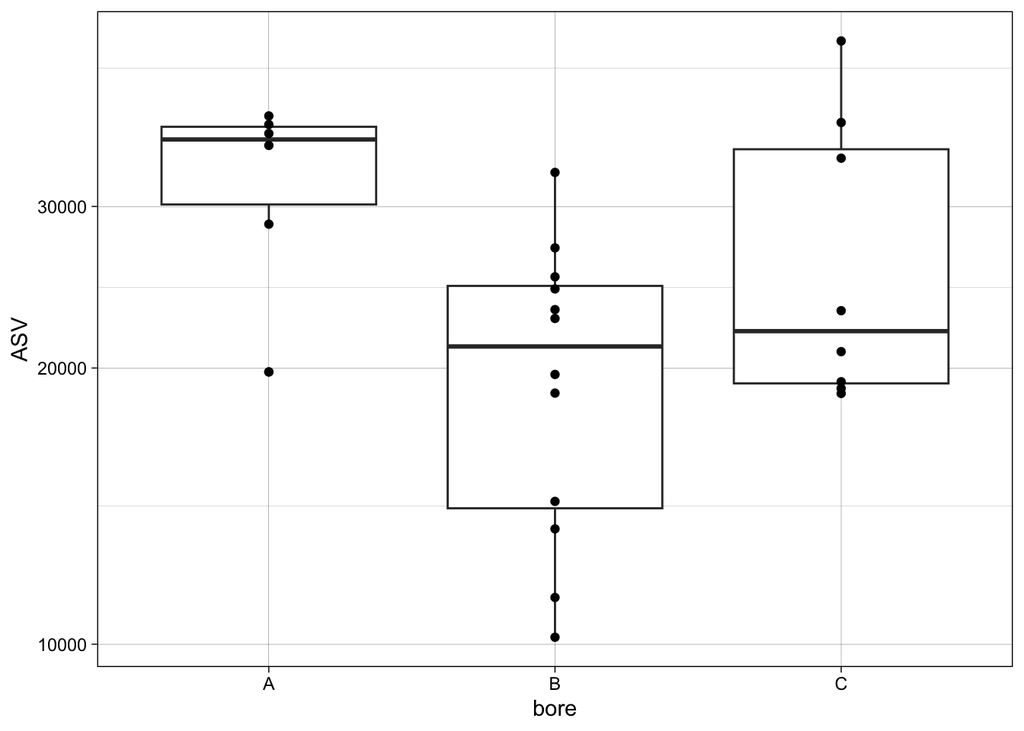

```r
#format a data table to combine summary data with sample variable data
ss <- sample_sums(ps)

#extract sample data
sd <- as.data.frame(sample_data(ps))

#merge the sample sums with the sample data
ss.df <-  merge(sd, data.frame("ASV" = ss), by="row.names")


y= 1000 # set a thershold for th minimum number of acceptable reads, can start as a guess

ss.df %>%
  ggplot(aes(bore, ASV))+
  geom_boxplot(outliers = T)+
  geom_point(position = position_dodge(width = 0.5))+
  scale_y_log10()
```

None of the samples have very low read counts, though bore B has several before 2000 k reads. This is still normal. I would be concerned when read counts are an order of magnitute lower.

## Prevalence filtering

> In many biological settings, the set of all organisms from all samples are well-represented in the available taxonomic reference database. When (and only when) this is the case, it is reasonable or even advisable to filter taxonomic features for which a high-rank taxonomy could not be assigned. Such ambiguous features in this setting are almost always sequence artifacts that don’t exist in nature. It should be obvious that such a filter is not appropriate for samples from poorly characterized or novel specimens, at least until the possibility of taxonomic novelty can be satisfactorily rejected. Phylum is a useful taxonomic rank to consider using for this purpose, but others may work effectively for your data. (Callahan et al. 2017. Workflow for Microbiome Data Analysis)

```r
# Create table, number of features for each phyla
table(tax_table(ps)[, "Phylum"], exclude = NULL)
```

```
##
##                  Acetothermia               Acidobacteriota
##                             4                            40
##              Actinobacteriota                Armatimonadota
##                            84                             5
##               Asgardarchaeota                  Bacteroidota
##                             1                           134
##              Bdellovibrionota            Caldatribacteriota
##                             2                            21
##                 Caldisericota                 Calditrichota
##                             2                             1
##              Campylobacterota                   Chloroflexi
##                             4                           130
##                Cloacimonadota          Coprothermobacterota
##                            10                             1
##                 Crenarchaeota                 Cyanobacteria
##                            15                             5
##                  Dadabacteria              Deferribacterota
##                             1                             1
##                  Deinococcota                  Dependentiae
##                             4                             3
##              Desulfobacterota                 Dictyoglomota
##                            36                             1
##               Elusimicrobiota                 Euryarchaeota
##                             1                            15
##                Fibrobacterota                    Firmicutes
##                             4                           842
##                Fusobacteriota               Gemmatimonadota
##                             2                            19
##              Halanaerobiaeota                 Halobacterota
##                            28                            22
##               Hydrogenedentes                  Hydrothermae
##                             3                             1
##              Latescibacterota Marinimicrobia (SAR406 clade)
##                             2                             2
##             Methylomirabilota                Modulibacteria
##                             1                             1
##                   Myxococcota                 Nanoarchaeota
##                            19                            11
##                  Nitrospirota               Patescibacteria
##                             3                            25
##               Planctomycetota                Proteobacteria
##                            59                           220
##                 Spirochaetota                   Sumerlaeota
##                            42                             3
##                  Synergistota              Thermoplasmatota
##                            24                            16
##                  Thermotogota             Verrucomicrobiota
##                            22                            23
##                           WS1                  Zixibacteria
##                             9                             2
##                          <NA>
##                            24
```

```r
#Shows the taxa for which only one feature was observed
```

Wow there are a lot of phyla. I’m not sure sure if its wise to remove anything since landfills are not exactly well characterized environments. If we wanted to remove the uncharacterized phyla then we could do the following.

```r
# ps_filt.2 <- subset_taxa(ps_filt.1, !is.na(Phylum) & !Phylum %in% c("", "uncharacterized"))
```

> …Explore the relationship of prevalence and total read count for each feature. Sometimes this reveals outliers that should probably be removed, and also provides insight into the ranges of either feature that might be useful. This aspect depends quite a lot on the experimental design and goals of the downstream inference, so keep these in mind. It may even be the case that different types of downstream inference require different choices here. There is no reason to expect ahead of time that a single filtering workflow is appropriate for all analysis. (Callahan et al. 2017. Workflow for Microbiome Data Analysis)

```r
# Compute prevalence of each feature, store as data.frame
prevdf <- apply(X = otu_table(ps),
               MARGIN = ifelse(taxa_are_rows(ps), yes = 1, no = 2),
               FUN = function(x){sum(x > 0)})
#It counts the number of samples in which a given OTU (feature) has a count greater than zero, effectively computing its prevalence (how many samples contain the OTU).

# Add taxonomy and total read counts to this data.frame
prevdf <- data.frame(Prevalence = prevdf,
                    TotalAbundance = taxa_sums(ps),
                    tax_table(ps))

plyr::ddply(prevdf, "Phylum", function(df1){cbind(mean(df1$Prevalence),sum(df1$Prevalence))})
```

```
##                           Phylum         1    2
## 1                   Acetothermia  1.000000    4
## 2                Acidobacteriota  1.300000   52
## 3               Actinobacteriota  1.666667  140
## 4                 Armatimonadota  1.200000    6
## 5                Asgardarchaeota  1.000000    1
## 6                   Bacteroidota  1.761194  236
## 7               Bdellovibrionota  1.000000    2
## 8             Caldatribacteriota  4.285714   90
## 9                  Caldisericota  1.000000    2
## 10                 Calditrichota  1.000000    1
## 11              Campylobacterota  4.750000   19
## 12                   Chloroflexi  1.361538  177
## 13                Cloacimonadota  2.000000   20
## 14          Coprothermobacterota 10.000000   10
```

[output cut: 37 more lines]

```r
#Calculates the mean prevalence across OTUs in that phylum, providing an average prevalence.
# Calculates the sum of prevalences, which is a total count of occurrences across all OTUs within each phylum.
```

Column one is the mean prevalence (how many samples contain the ASV) of an ASV in that phylum Column two is the total count of occurances across all OTUs

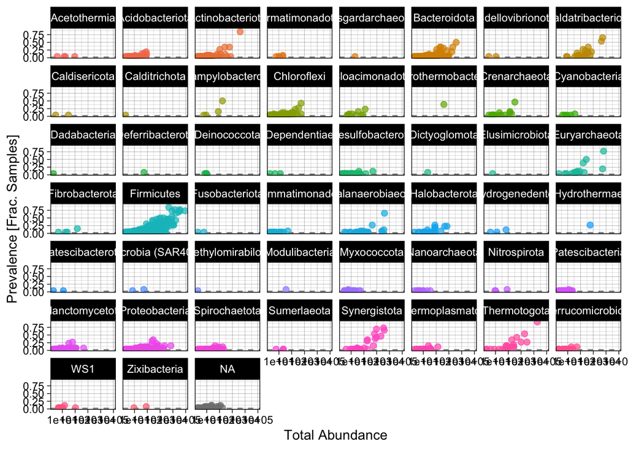

```r
ggplot(prevdf, aes(TotalAbundance, Prevalence / nsamples(ps), color=Phylum)) +
  # Include a guess for parameter
  geom_hline(yintercept = 0.02, alpha = 0.5, linetype = 2) +
  geom_point(size = 2, alpha = 0.7) +
  scale_x_log10() +
  xlab("Total Abundance") +
  ylab("Prevalence [Frac. Samples]") +
  facet_wrap(~Phylum) +
  theme(legend.position="none")
```

> How and whether to conduct independent filtering of data prior to conducting DA tests are other important open questions regarding microbiome data analysis7. Although statistical arguments regarding the validity of independent filtering are beyond the scope of this work, intuitively it is reasonable to exclude features found in only a small number of samples (regardless of which groups those samples are in). The basic reason for this is that otherwise the burden of multiple-test correction becomes so great as to nearly prohibit identifying any differentially abundant features. Despite this drawback, many tools identified large numbers of significant ASVs in the unfiltered data. However, these significant ASVs tended to be more tool-specific in the unfiltered data and there was much more variation in the percentage of significant ASVs across tools. Accordingly, we would suggest performing prevalence filtering (e.g., at 10%) of features prior to DA testing, although we acknowledge that more work is needed to estimate an optimal cut-off rather than just arbitrarily selecting one.[(Nearing et al. 2022)](https://www.nature.com/articles/s41467-022-28034-z)

```r
# Define prevalence threshold as 5% of total samples
prevalenceThreshold = 0.05 * nsamples(ps)
prevalenceThreshold
```

```
## [1] 1.3
```

```r
# Execute prevalence filter, using `prune_taxa()` function
keepTaxa = rownames(prevdf)[(prevdf$Prevalence >= prevalenceThreshold)]

ps_filt = prune_taxa(keepTaxa, ps)


ps
```

```
## phyloseq-class experiment-level object
## otu_table()   OTU Table:         [ 1950 taxa and 26 samples ]
## sample_data() Sample Data:       [ 26 samples by 12 sample variables ]
## tax_table()   Taxonomy Table:    [ 1950 taxa by 7 taxonomic ranks ]
```

```r
ps_filt
```

```
## phyloseq-class experiment-level object
## otu_table()   OTU Table:         [ 554 taxa and 26 samples ]
## sample_data() Sample Data:       [ 26 samples by 12 sample variables ]
## tax_table()   Taxonomy Table:    [ 554 taxa by 7 taxonomic ranks ]
```

We can use the `ps_filt` object later when we do differential abundance testing

# Check out co-variates

There are four main variables in this dataset that are of interest: * temperature * depth * % moisture * % total carbon

It’s worth exploring these variables on their own so we know how we want to plot up our microbial data later.

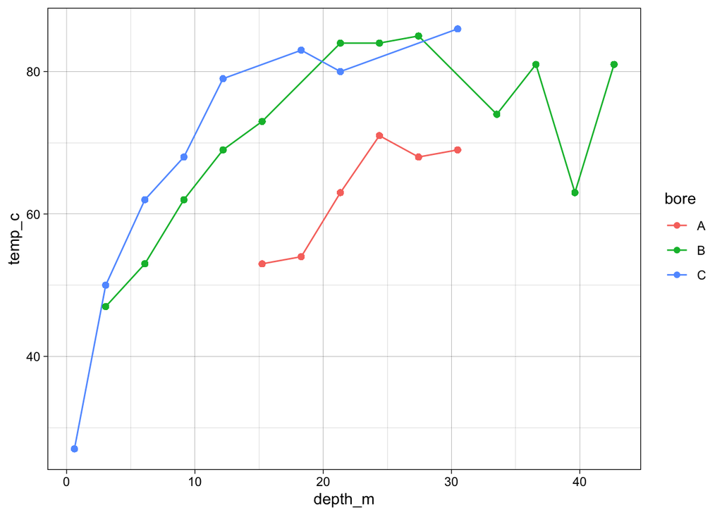

```r
ps.df %>%
  ggplot(aes(depth_m, temp_c, color = bore))+
  geom_line()+
  geom_point()
```

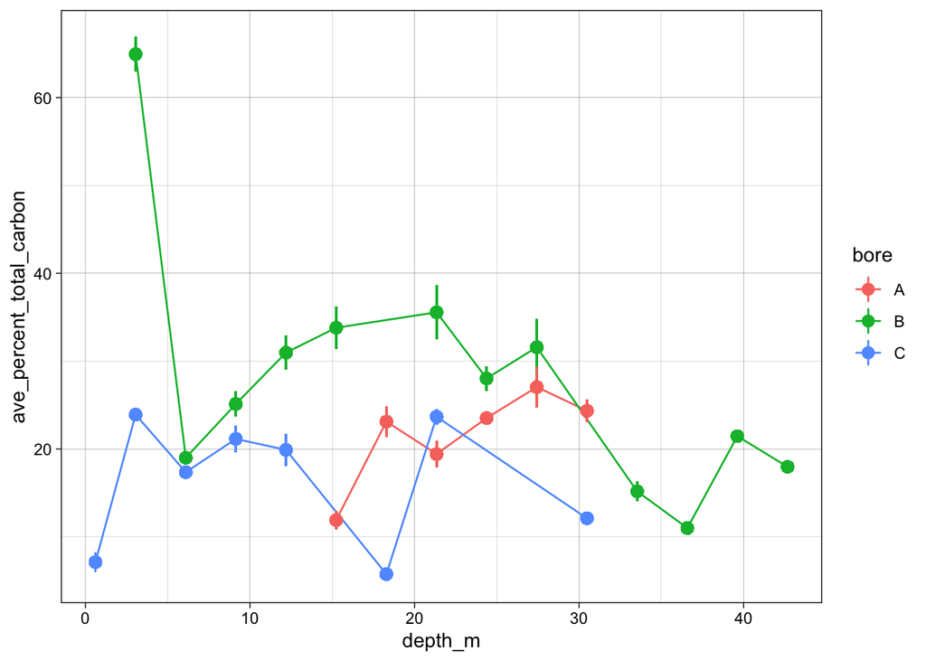

```r
ps.df %>%
  ggplot(aes(depth_m, ave_percent_total_carbon, color = bore))+
  geom_line()+
  geom_point()+
  geom_pointrange(aes(ymin = ave_percent_total_carbon - std_percent_total_carbon, ymax =  ave_percent_total_carbon + std_percent_total_carbon)) #add error bars
```

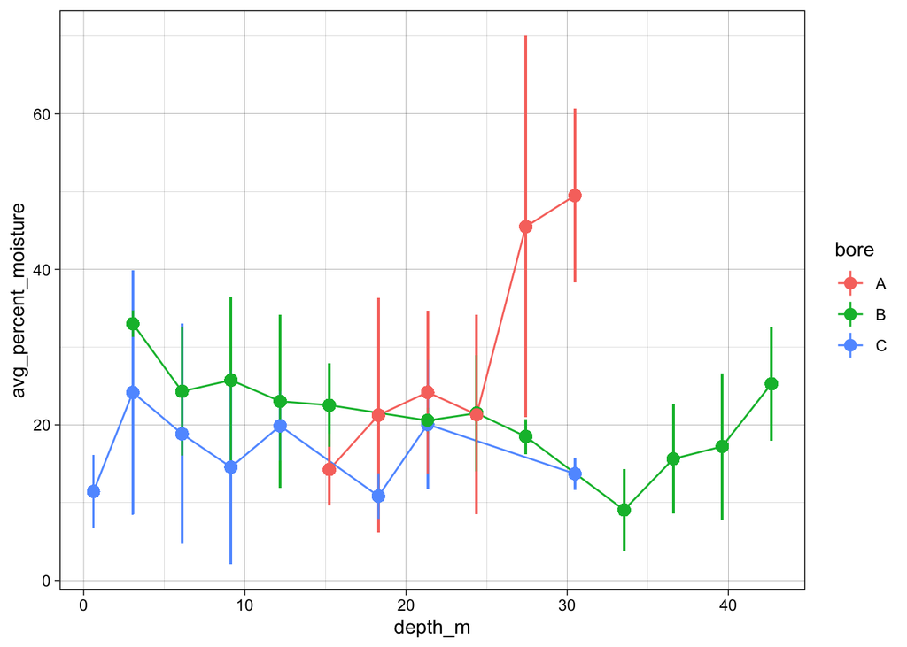

```r
ps.df %>%
  ggplot(aes(depth_m, avg_percent_moisture, color = bore))+
  geom_line()+
  geom_point()+
  geom_pointrange(aes(ymin = avg_percent_moisture - std_percent_moisture, ymax =  avg_percent_moisture + std_percent_moisture)) #add error bars
```

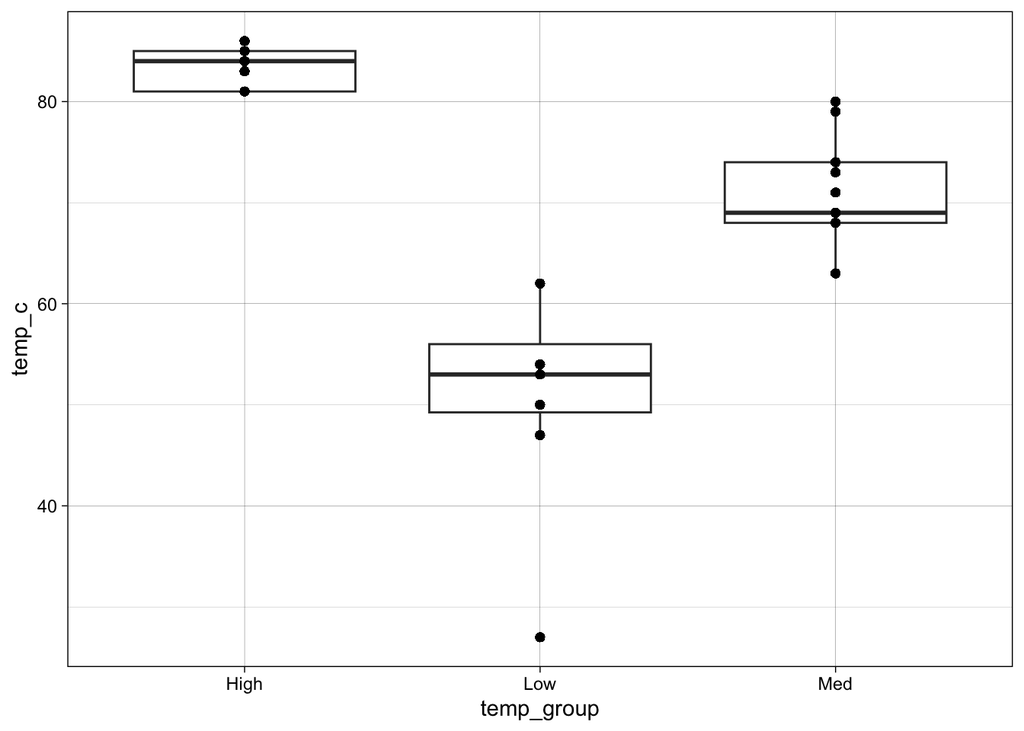

```r
ps.df %>%
  ggplot(aes(temp_group, temp_c))+
  geom_boxplot()+
  geom_point()
```

First I’m going to change the the groups to be >72 and less than 72 because that is when methanogensis is inhibited in landfills according to De la Cruz et al. 2021. These groups are arbitrary as far as I can tell.

There is also a temperature outlier which we may want to remove so we have more even sample groups.

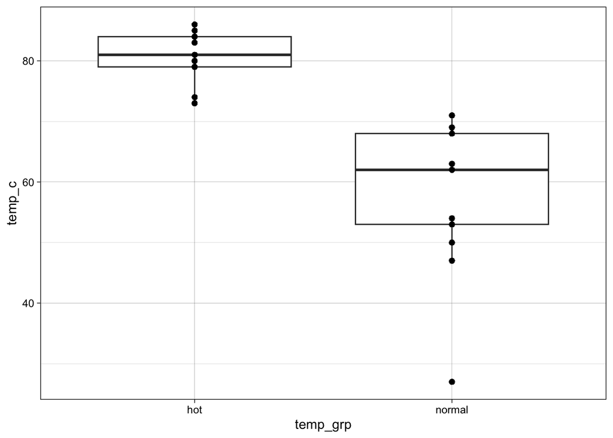

```r
ps.df <- ps.df %>%
  mutate(temp_grp = ifelse(temp_c > 72, "hot", "normal")) # create a new variable called "temp_grp", if the temperature is about 72, call it "hot", otherwise, "normal"


ps.df %>%
  ggplot(aes(temp_grp, temp_c))+
  geom_boxplot()+
  geom_point()
```

# Data transformation

For a lot of data visualization, we’ll want to look at relative rather than absolute abundance, so here we can do that transformation and make a dataframe on the transformed phyloseq object.

```r
ps_rel <- transform_sample_counts(ps, function(OTU) OTU/sum(OTU))

ps_rel.df <-psmelt(ps_rel)

#make sure to add the new category to this dataframe as well
ps_rel.df <- ps_rel.df %>%
  mutate(temp_grp = ifelse(temp_c > 72, "hot", "normal")) # create a new variable called "temp_grp", if the temperature is about 72, call it "hot", otherwise, "normal"
```

# Explore taxonomy

```r
ps_genus <- tax_glom(ps, taxrank= "Genus")

ps_genus.df <- psmelt(ps_genus)


ps_genus.df <- ps_genus.df %>%
  mutate(path = paste(Phylum, Class, Order, Family, Genus, sep="-")) %>%
  group_by(path) %>%
  summarise(count = sum(Abundance)) %>%
  ungroup()

# Convert the data to a format compatible with sunburstR
sb_data <- ps_genus.df %>%
  select(path, count)


# Create the sunburst plot
sunburst(sb_data, count = TRUE, legend = T)
```

[interactive chart not shown]

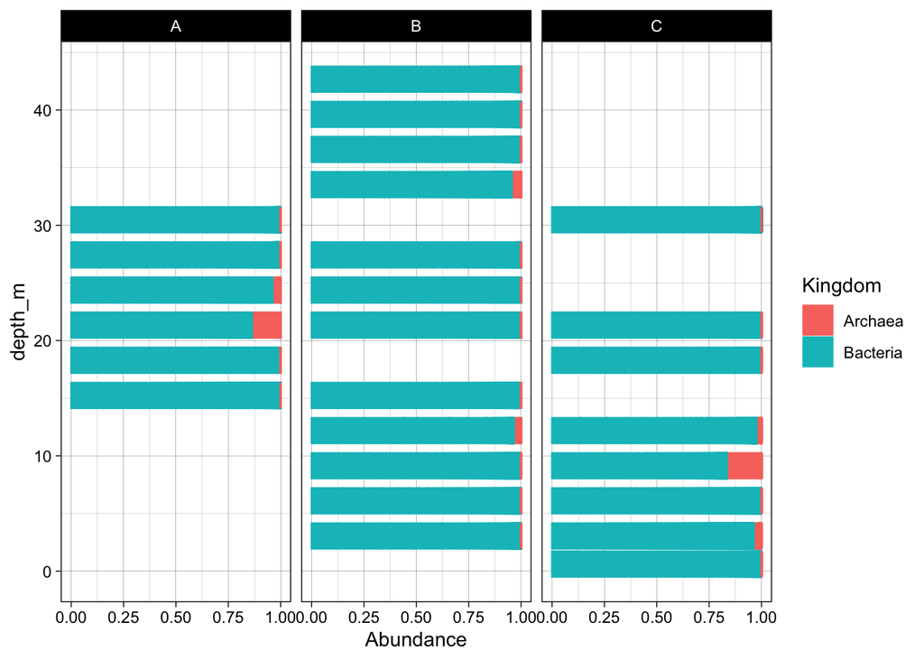

```r
ps_rel.df %>%
  ggplot(aes(depth_m, Abundance, color = Kingdom, fill = Kingdom))+
  geom_bar(stat="identity")+
  coord_flip()+
  facet_wrap(~bore)
```

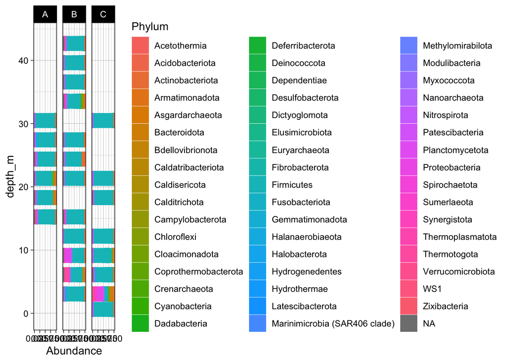

```r
ps_rel.df %>%
  ggplot(aes(depth_m, Abundance, color = Phylum, fill = Phylum))+
  geom_bar(stat="identity")+
  coord_flip()+
  facet_wrap(~bore)
```

There are so many Phyla, maybe this time it makes sense to use our 5% prevalance filtered phyloseq object

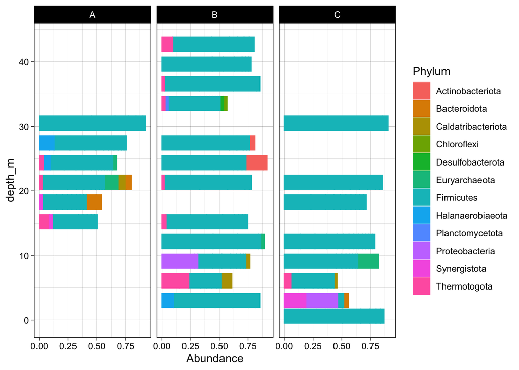

```r
#transform sample counts
ps_filt_rel <- transform_sample_counts(ps_filt, function(OTU) OTU/sum(OTU))

#make a data frame
ps_filt_rel.df <- psmelt(ps_filt_rel)

ps_filt_rel.df %>%
  filter(Abundance > 0.02) %>%
  ggplot(aes(depth_m, Abundance, color = Phylum, fill = Phylum))+
  geom_bar(stat="identity")+
  coord_flip()+
  facet_wrap(~bore)
```

# Alpha diversity

There are many different alpha diversity metrics we can use.

The `phyloseq` package can calculate and plot alpha diversity for us using the `plot_richness` function

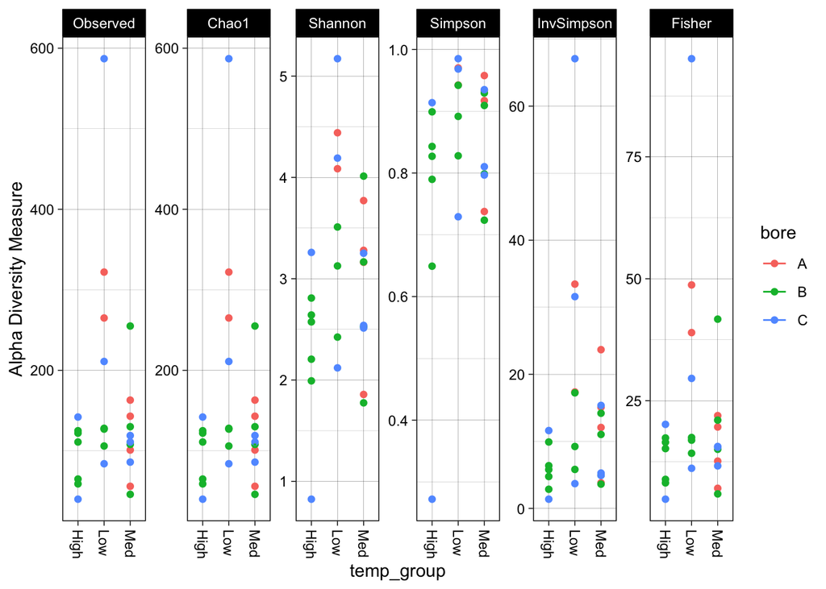

```r
plot_richness(ps, measures = c("Observed", "Chao1", "Shannon", "Simpson", "InvSimpson", "Fisher"), x = "temp_group", color = "bore")
```

The diveristy plots made by the `phyloseq` package are not always the most visually appealing and harder to manipulate.

We can also calculate alpha diversity using the `microbiome` package

```r
#calculate alpha diversity
diversity <- microbiome::alpha(ps, index = "all")
```

```
## Observed richness
```

```
## Other forms of richness
```

```
## Diversity
```

```
## Evenness
```

```
## Dominance
```

```
## Rarity
```

```r
#add a column in the diversity data from the rownames (which contain the sample ids)
diversity$id <- rownames(diversity)

#extract the sample metadata from the phyloseq object
md <- data.frame(sample_data(ps))

#merge the calculated diversity metrics to the metadata by the sample id column, now we have a diversity data with metadata to play with
diversity.df <- merge(diversity, md, by = "id")

diversity.df <- diversity.df %>%
   mutate(temp_grp = ifelse(temp_c > 72, "hot", "normal"))
```

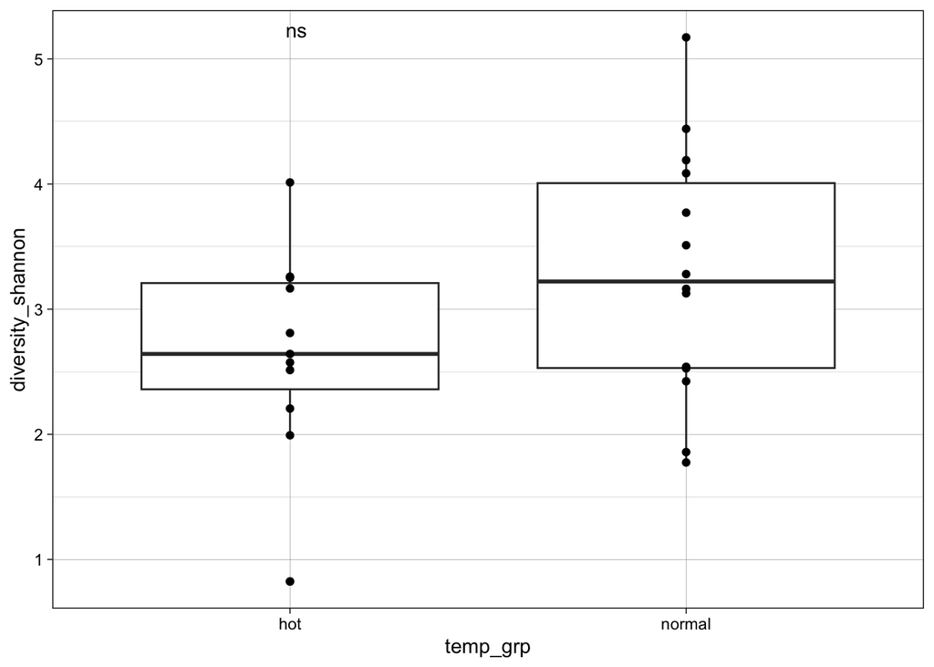

```r
diversity.df %>%
  filter(temp_c >45) %>%
ggplot(aes(temp_grp, diversity_shannon))+
  geom_boxplot()+
  geom_point()+
  stat_compare_means(method = "wilcox.test", #test significance
                     label = "p.signif")
```

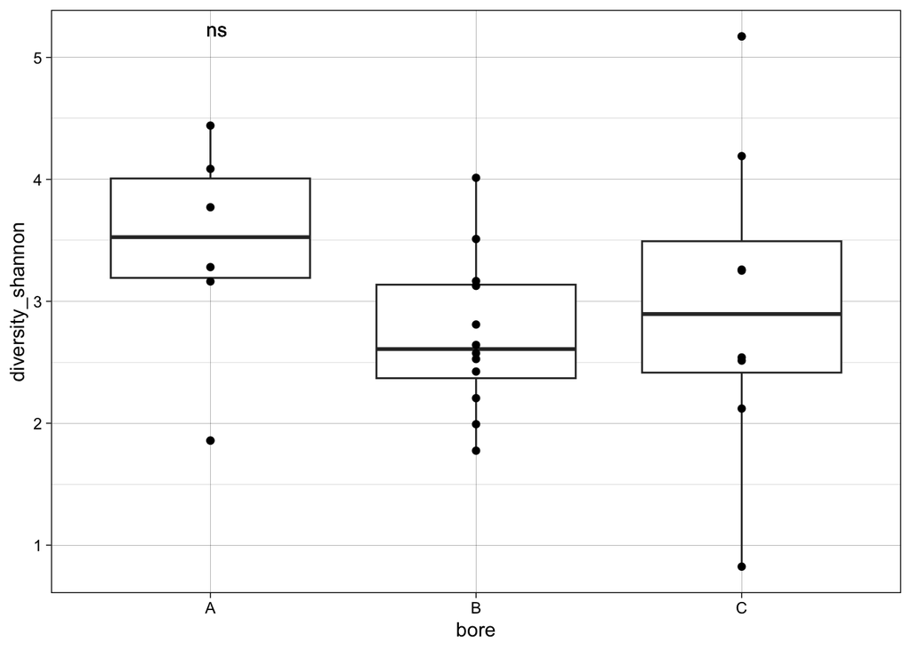

```r
ggplot(diversity.df, aes(bore, diversity_shannon))+
  geom_boxplot()+
  geom_point()+
  stat_compare_means(method = "wilcox.test",
                     label = "p.signif")
```

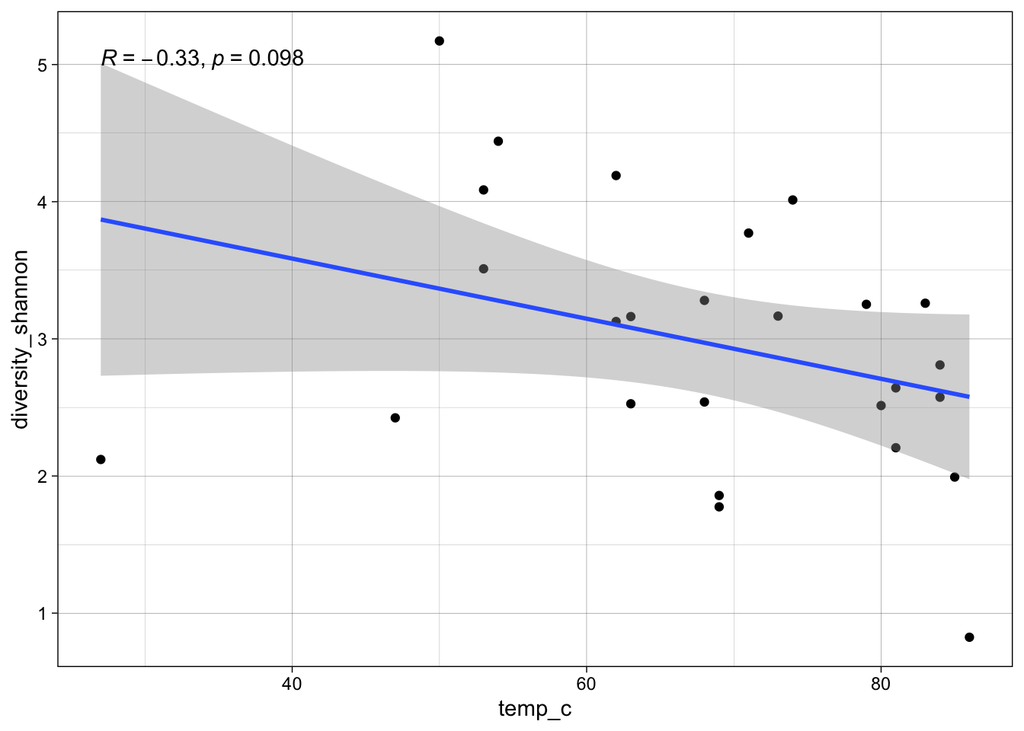

```r
ggplot(diversity.df, aes(temp_c, diversity_shannon))+
  geom_point()+
  geom_smooth(method = "lm")+ #linear regression
     stat_cor() #adds the R^2 and p value directly to the plot
```

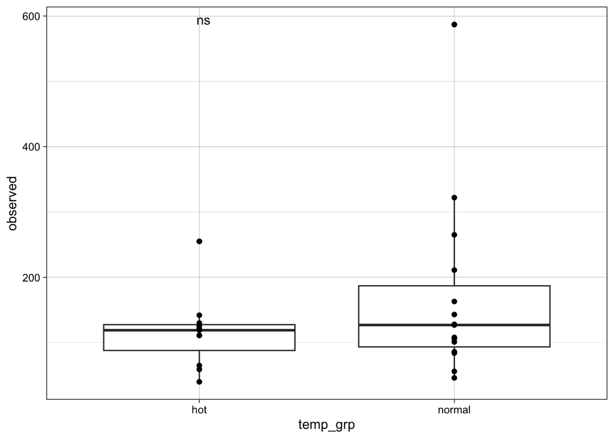

```r
ggplot(diversity.df, aes(temp_grp, observed))+
  geom_boxplot()+
  geom_point()+
  stat_compare_means(method = "wilcox.test", #test significance
                     label = "p.signif")
```

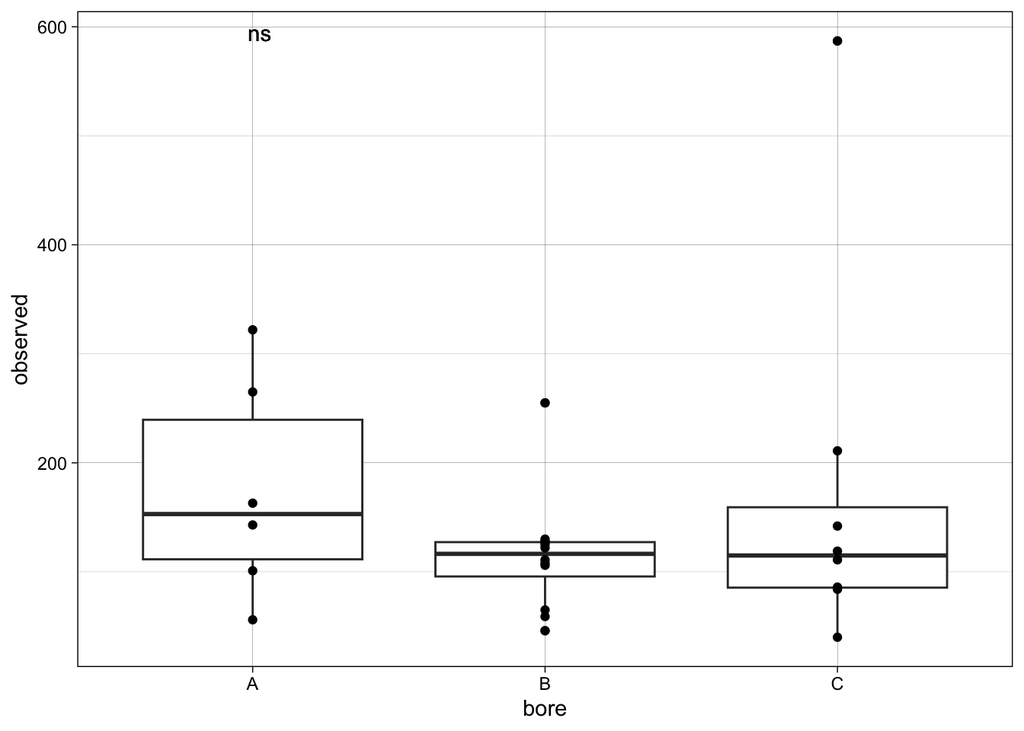

```r
ggplot(diversity.df, aes(bore, observed))+
  geom_boxplot()+
  geom_point()+
  stat_compare_means(method = "wilcox.test",
                     label = "p.signif")
```

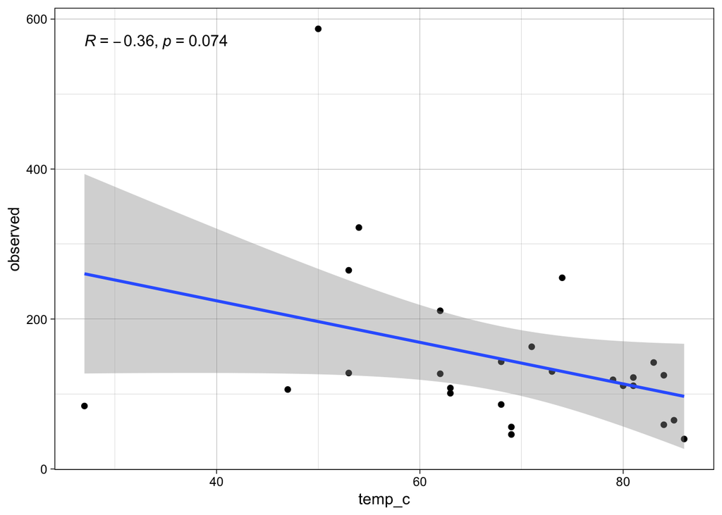

```r
ggplot(diversity.df, aes(temp_c, observed))+
  geom_point()+
  geom_smooth(method = "lm")+ #linear regression
     stat_cor() #adds the R^2 and p value directly to the plot
```

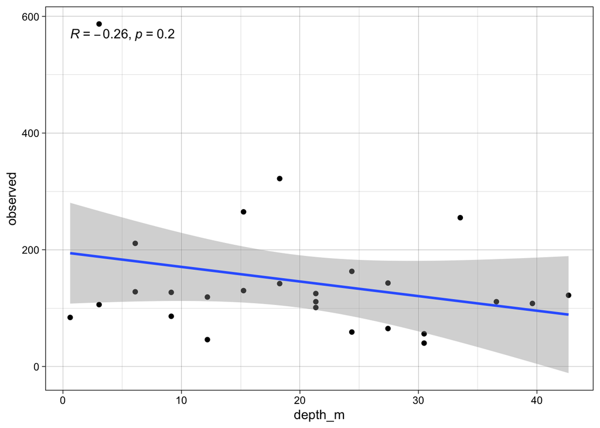

```r
ggplot(diversity.df, aes(depth_m, observed))+
  geom_point()+
  geom_smooth(method = "lm")+ #linear regression
     stat_cor() #adds the R^2 and p value directly to the plot
```

Remove the one temperature outlier to see if the statistics change.

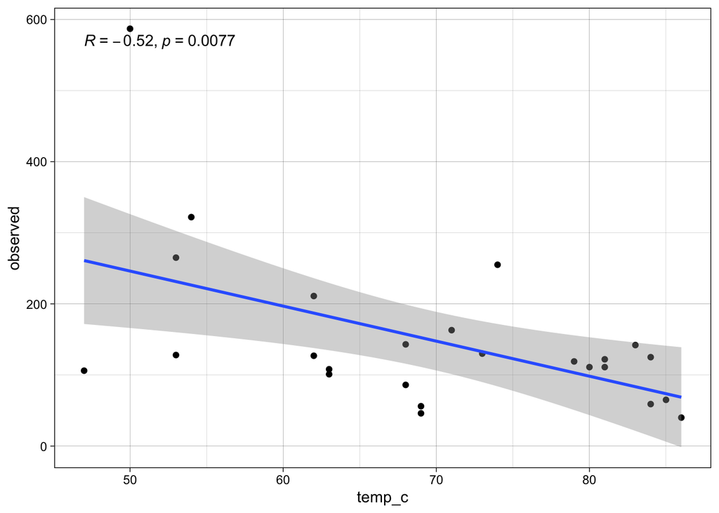

```r
diversity.df %>%
  filter(temp_c > 45) %>%
ggplot( aes(temp_c, observed))+
  geom_point()+
  geom_smooth(method = "lm")+ #linear regression
     stat_cor() #adds the R^2 and p value directly to the plot
```

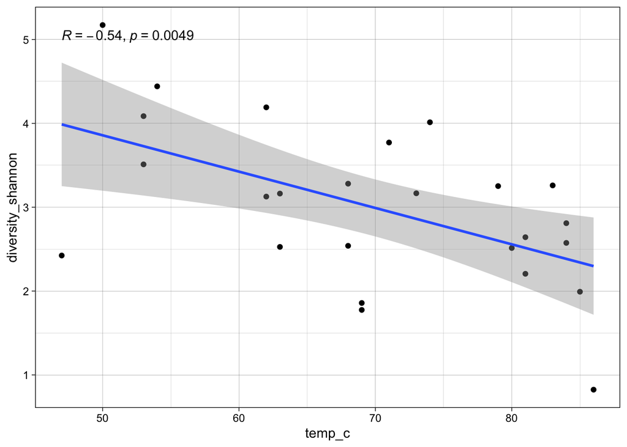

```r
diversity.df %>%
  filter(temp_c > 45) %>%
ggplot(aes(temp_c, diversity_shannon))+
  geom_point()+
  geom_smooth(method = "lm")+ #linear regression
     stat_cor() #adds the R^2 and p value directly to the plot
```

There’s a pretty significant negative linear correlation between temperature and diversity when we remove that one outlier sample.

# Beta diversity ordination

```r
nmds_bray <- ordinate(ps, method="NMDS", distance = "bray")
```

```
## Square root transformation
## Wisconsin double standardization
## *** Best solution repeated 2 times
```

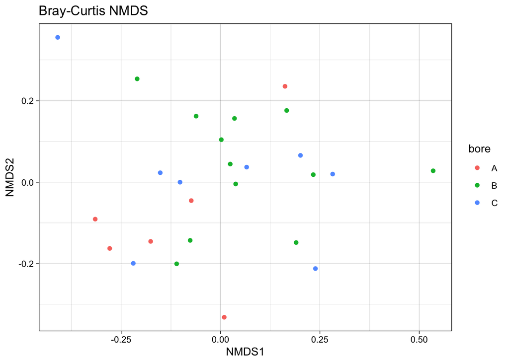

```r
plot_ordination(ps, nmds_bray, color = "bore",  title = "Bray-Curtis NMDS")
```

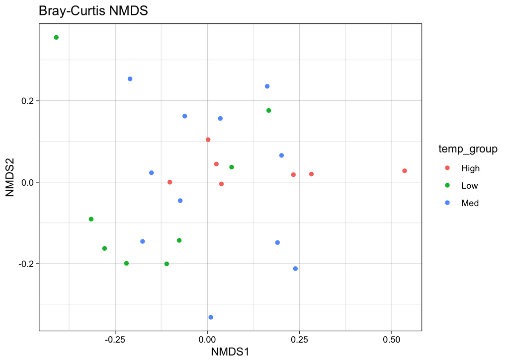

```r
plot_ordination(ps, nmds_bray, color = "temp_group",  title = "Bray-Curtis NMDS")
```

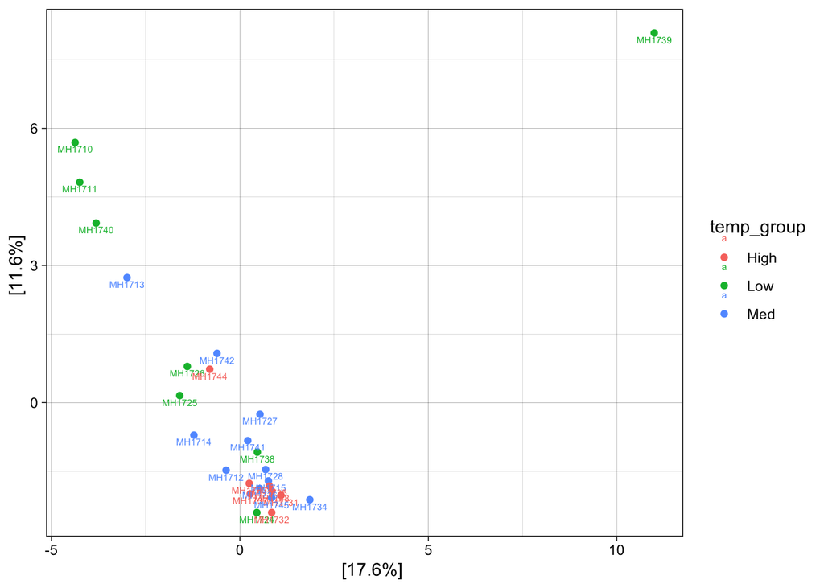

```r
#Center log ratio the phyloseq file
ps_clr <- microbiome::transform(ps, "clr")

#Equivalant of PCA
ord_clr <- phyloseq::ordinate(ps_clr, "RDA")

plot_ordination(ps_clr, ord_clr, color = "temp_group", label = "id")
```

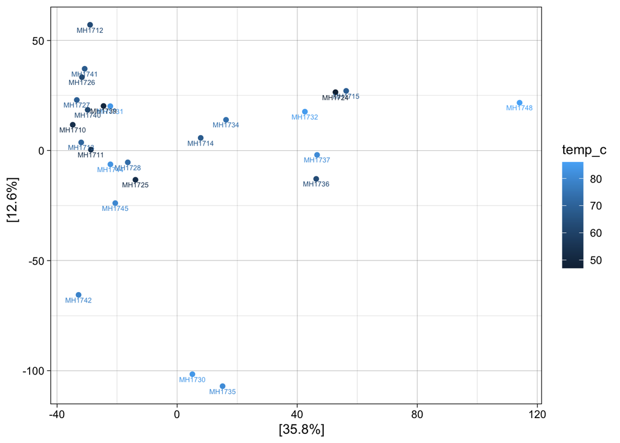

```r
ps_clr.filt <- subset_samples(ps, temp_c > 45)

ord_clr.filt <- phyloseq::ordinate(ps_clr.filt, "RDA")

plot_ordination(ps_clr.filt, ord_clr.filt, color = "temp_c", label = "id")
```

```r
ps_fix <- tax_fix(ps)

sample_data(ps_fix)$average_percent_moisture
```

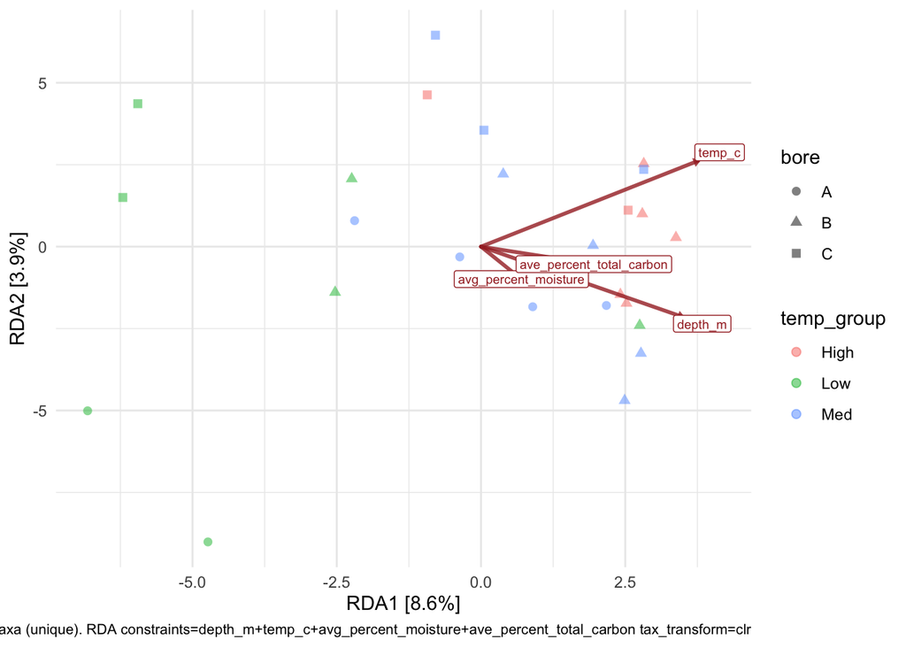

```r
 ps_fix %>%
   subset_samples(temp_c > 45) %>%
  tax_transform("clr") %>%
  ord_calc(
    constraints = c("depth_m", "temp_c", "avg_percent_moisture", "ave_percent_total_carbon"),
    # method = "RDA", # Note: you can specify RDA explicitly, and it is good practice to do so, but microViz can guess automatically that you want an RDA here (helpful if you don't remember the name?)
    scale_cc = FALSE # doesn't make a difference
  ) %>%
  ord_plot(size = 2, alpha = 0.5, shape = "bore", color = "temp_group")
```

# PERMANOVA TEST

```r
#remove the temperature outlier
ps.2 <- subset_samples(ps, temp_c > 45)

#transform center log ratio
ps.2_clr <- microbiome::transform(ps.2, "clr")

#calculate euclidean distance matrix
dist_euc <- phyloseq::distance(ps.2_clr, method="euclidean")

#get metadata
metadata <- data.frame(sample_data(ps.2))

#add temp category
metadata <- metadata %>%  mutate(temp_grp = ifelse(temp_c > 72, "hot", "normal"))

#conduct permanova and extract the results
results <- pairwiseAdonis::pairwise.adonis(dist_euc, metadata[, "temp_grp"], perm = 10000, p.adjust.m = "bonferroni")

results[,3:5] <- round(results[,3:5], 2)

results
```

```
##           pairs Df SumsOfSqs F.Model   R2    p.value p.adjusted sig
## 1 normal vs hot  1   2235.56    1.41 0.06 0.03059694 0.03059694   .
```

Significantly different

```r
#conduct permanova and extract the results
results <- pairwiseAdonis::pairwise.adonis(dist_euc, metadata[, "bore"], perm = 10000, p.adjust.m = "bonferroni")

results[,3:5] <- round(results[,3:5], 2)

results
```

```
##    pairs Df SumsOfSqs F.Model   R2    p.value p.adjusted sig
## 1 A vs B  1   2557.51    1.89 0.11 0.00599940 0.01799820   .
## 2 A vs C  1   2494.82    1.24 0.10 0.09689031 0.29067093
## 3 B vs C  1   2055.82    1.45 0.08 0.01909809 0.05729427
```

A and B have slightly different microbial communities